# Arbeiten mit Bildern

## Import der Bibliotheken

```python
import numpy as np
import scipy
import cv2
import matplotlib.pyplot as plt
import plotly
import plotly.express as px
import plotly.graph_objects as go
from plotly.subplots import make_subplots
```

### Laden eines Testbildes

```python
image_baboon=cv2.imread('./Images/baboon.png', cv2.IMREAD_COLOR_RGB)
# image taklen from https://github.com/scijs/baboon-image/blob/master/baboon.png
# image is loaded as BRG image. convert to RGB
```

#### Anzeigen der Datenstruktur des Bildes

Dieses Farb - Bild wird als numpy ndarray, einer v x u x 3 Zahlen - Matrix geladen.

Die Koordinaten u, v repraesentieren hier die Pixelposition im Bild, die 3. Koordinate die jeweiligen Farbkanäle Rot, Gruen, und Blau (rgb)

Bildgröße und Datentyp können durch folgende Befehle abgefragt werden.

```python
dataType = image_baboon.dtype
imageShape = image_baboon.shape
print(f'Datentyp des Bildes: {dataType}')
print(f'fortmat des Bildes: {imageShape}')
```

```
Datentyp des Bildes: uint8
fortmat des Bildes: (512, 512, 3)
```

### Anzeigen des Bildes

#### Inline Anzeige des Bildes

Bewegen den Mauszeige über das Bild, dann können Sie sowohl die Werte der Farbkanäle als auch die dazugehörigen Pixelkoordinaten auslesen.

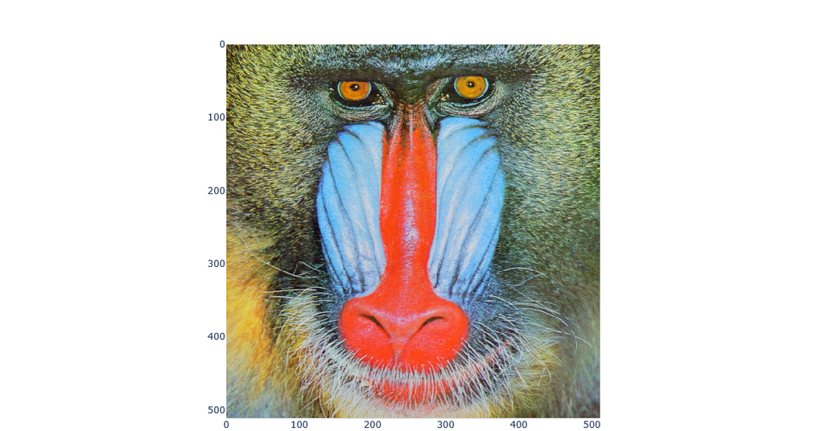

```python
# Anzeige des Bildes
height, width = image_baboon.shape[:2]
fig = px.imshow(image_baboon)
fig.update_layout(width=width, height=height + 50, margin=dict(l=0, r=0, t=50, b=0))
fig.show()
```

### Farbkanäle einzeln Anzeigen

Die Farbkanaele des Bildes lassen sich einzeln ansteuern

Roter Kanal `image_baboon[:,:,0]`

Grüner Kanal `image_baboon[:,:,1]`

Blauer Kanal `image_baboon[:,:,2]`

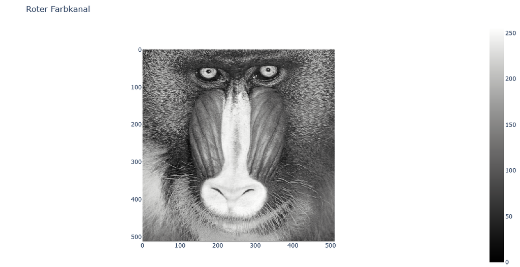

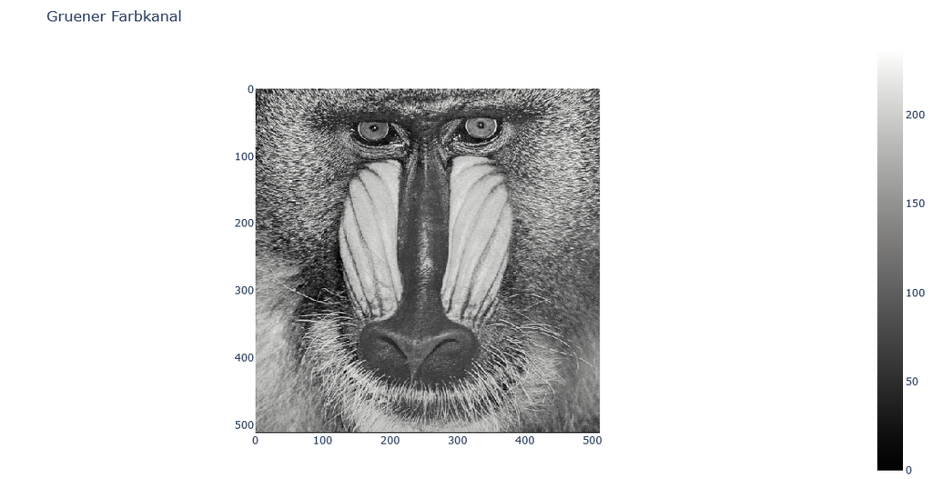

[figure not shown]

```python
image_baboon_red = image_baboon[:,:,0]
image_baboon_green = image_baboon[:,:,1]
image_baboon_blue = image_baboon[:,:,2]

## Plot the images
height, width = image_baboon.shape[:2]

# Anzeige des roten Kanals
fig = px.imshow(image_baboon_red, color_continuous_scale='gray', title='Roter Farbkanal')
fig.update_layout(width=width, height=height + 50, margin=dict(l=0, r=0, t=50, b=0))
fig.show()

# Anzeige des grünen Kanals
fig = px.imshow(image_baboon_green, color_continuous_scale='gray', title='Gruener Farbkanal')
fig.update_layout(width=width, height=height + 50, margin=dict(l=0, r=0, t=50, b=0))
fig.show()

# Anzeige des blauen Kanals
fig = px.imshow(image_baboon_blue, color_continuous_scale='gray', title='Blauer Farbkanal')
fig.update_layout(width=width, height=height + 50, margin=dict(l=0, r=0, t=50, b=0))
fig.show()
```

### Filterung nach einer Speziellen Farbe / Farbbereich

#### Nase

Die Rote Nase lässt sich leicht herausfiltern, da diese kaum andere Farbkomponenten besitzt

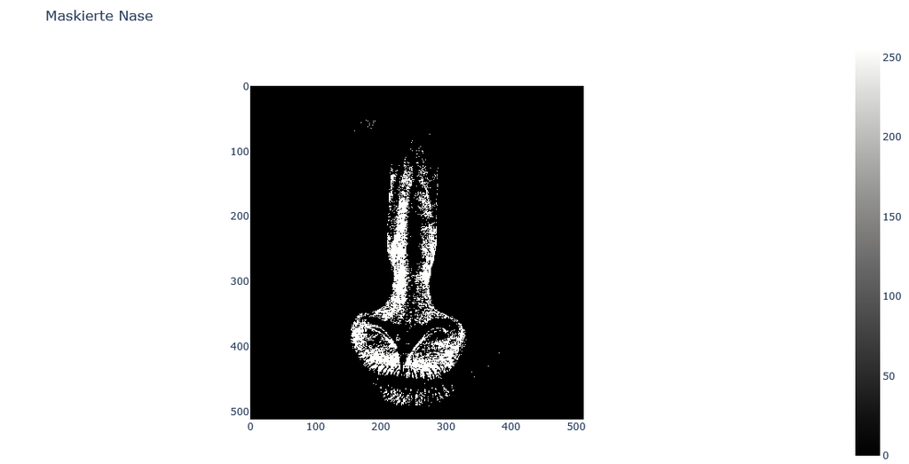

```python
nose = cv2.inRange(image_baboon, (150, 0, 0), (255, 80, 80))

# Anzeige der Nase
height, width = nose.shape[:2]
fig = px.imshow(nose, color_continuous_scale='gray', title='Maskierte Nase')
fig.update_layout(width=width, height=height + 50, margin=dict(l=0, r=0, t=50, b=0))
fig.show()
```

#### Augen

Nachdem eben die Nase des Affen gefiltert wurde sollen nun die Augen gefiltert werden. Versuchen Sie den Filter so anzupassen dass nur die zu den orangenen Augen gehörenden Pixel detektiert werden. Nutzen Sie hierfür das oben stehende Farbbild und lesen Sie die einzelnen Farbwerte mit dem Mauszeiger ab.

**Achtung** *Sie werden feststellen dass dies etwas schwerer umsetzbar ist, die orangenen Augen lassen sich nicht so einfach von den restlichen Farbtönen trennen*

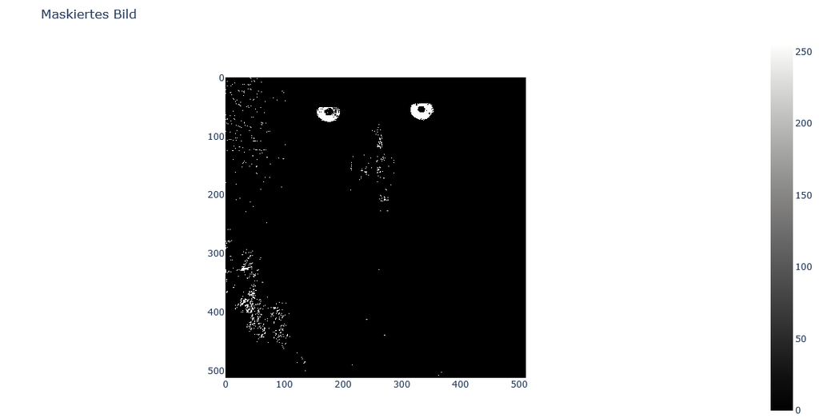

```python
## Verändern Sie die Filterwerte durch Anpassen der unteren Schranke und der oberen Schranke
jaw = cv2.inRange(image_baboon, (150, 100, 0), (255, 255, 50))

# Anzeige der Nase
height, width = jaw.shape[:2]
fig = px.imshow(jaw, color_continuous_scale='gray', title='Maskiertes Bild')
fig.update_layout(width=width, height=height + 50, margin=dict(l=0, r=0, t=50, b=0))
fig.show()
```

#### Wechsel des Farbraums

Der RGB-Farbraum entspricht nicht unbedingt der menschlichen Farbwahrnehmung, in dem Sinne, dass ähnliche Farben (r,g,b) auch zahlenmäßig nahe beieinanderliegen. Der HSV Farbraum parametrisiert die Farben so, dass ähnliche Farben jetzt auch örtlich nebeneinander liegen.

Das Bild lässt sich nun deutlich einfacher nach dem Farbtonwert filtern (hue). Um gute Parameter zu bekommen geht man schrittweise vor. 1) Farbtonwertebereich einschränken, 2) Sättigungsbereich einschränken 3) Helligkeitsbereich einschränken. Man startet mit einem Filterbereich von inRange(image_baboon_hsv, `(0, 0, 0), (255, 255, 255))` und passt die Schwellen von rechts nach links an. Man iteriert sich dann zu: `image_baboon_hsv, (14, 220, 60), (25, 255, 255)`

[figure not shown]

```python
# konvertiere RGB zu HSV
image_baboon_hsv = cv2.cvtColor(image_baboon, cv2.COLOR_RGB2HSV)

## Verändern Sie die Filterwerte durch Anpassen der unteren Schranke und der oberen Schranke
jaw = cv2.inRange(image_baboon_hsv, (14, 220, 60), (25, 255, 255))

# Anzeige des Bildes
# Achtung: Plotly kann im HSV-Raum abgespeicherte Bilder nicht darstellen. Das Dargestellte Bild ist somit ein Falschfarbenbild
height, width = image_baboon_hsv.shape[:2]
fig = px.imshow(image_baboon_hsv, color_continuous_scale='hsv', title='Bild im HSV Raum')
fig.update_layout(width=width, height=height + 50, margin=dict(l=0, r=0, t=50, b=0))
fig.show()

# Anzeige der Nase
height, width = jaw.shape[:2]
fig = px.imshow(jaw, color_continuous_scale='gray', title='Bild im HSV Raum')
fig.update_layout(width=width, height=height + 50, margin=dict(l=0, r=0, t=50, b=0))
fig.show()
```

[output not shown]

### Erkennung von Verkehrszeichen

#### Aufgabe

```python
image_verkehr=cv2.imread('./Images/verkehr.jpg', cv2.IMREAD_COLOR_RGB)

# konvertiere RGB zu HSV
image_verkehr_hsv = cv2.cvtColor(image_verkehr, cv2.COLOR_RGB2HSV)
```

```python
# Anzeige der Bilder
# Achtung: Plotly kann im HSV-Raum abgespeicherte Bilder nicht darstellen. Das Dargestellte Bild ist somit ein Falschfarbenbild
fig = px.imshow(image_verkehr, color_continuous_scale='hsv', title='Bild im RGB Raum')
fig.update_layout(width = 500, height=400, margin=dict(l=0, r=0, t=50, b=0))
fig.show()

# Anzeige der Nase
fig = px.imshow(image_verkehr_hsv, color_continuous_scale='gray', title='Bild im HSV Raum')
fig.update_layout(width = 500, height=400, margin=dict(l=0, r=0, t=50, b=0))
fig.show()
```

[output not shown]

```python
####
#### ENTER CODE HERE
####

#filter_vorfahrt =
#filter_zebra =
#filter_tempo =


## Verändern Sie die Filterwerte durch Anpassen der unteren Schranke und der oberen Schranke
filter_vorfahrt = cv2.inRange(image_verkehr_hsv, (16, 170, 50), (22, 255, 255))
filter_zebra = cv2.inRange(image_verkehr_hsv, (100, 180, 50), (110, 255, 255))
filter_tempo = cv2.inRange(image_verkehr_hsv, (170, 100, 50), (178, 255, 254))


#
fig = px.imshow(filter_vorfahrt, color_continuous_scale='gray', title='Filter Vohrfahrt')
fig.update_layout(width = 500, height=400, margin=dict(l=0, r=0, t=50, b=0))
fig.show()

fig = px.imshow(filter_zebra, color_continuous_scale='gray', title='Filter Zebra')
fig.update_layout(width = 500, height=400, margin=dict(l=0, r=0, t=50, b=0))
fig.show()

fig = px.imshow(filter_tempo, color_continuous_scale='gray', title='Filter Tempo')
fig.update_layout(width = 500, height=400, margin=dict(l=0, r=0, t=50, b=0))
fig.show()
```

[output not shown]

## Graustufenbilder

#### Code Generierung mit Hilfe generativer KI

Wandeln Sie das Bild `image_verkehr` in ein Graustufenbild um. Verwenden Sie dazu keinen vorgefertigten Befehl des Bildverarbeitungspaketes openCV (cv2.). Dokumentieren Sie Ihren Code sodass die Grundidee verstanden werden kann. Vergleichen Sie Graustufenbild mit dem Ergebniss der OpenCV Funktion `cv2.cvtColor(image_verkehr, cv2.COLOR_RGB2Gray)` indem Sie die beiden auf unterschiedliche Weise erzeugten Graustufenbilder voneinander abziehen. Bringen Sie alle 3 Bilder danach zur Anzeige.

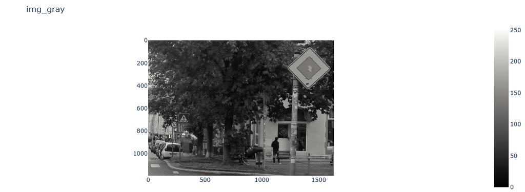

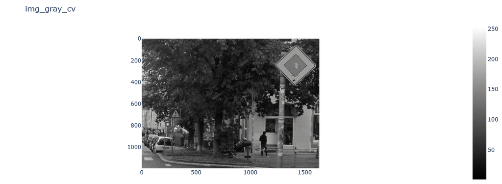

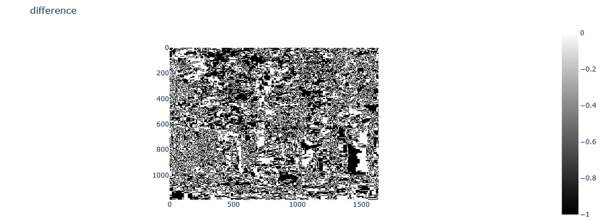

```python
####
#### ENTER CODE HERE
####



# img_gray = np.dot(image_verkehr[:,:,:3], [0.33, 0.33, 0.33])

#img_gray  =1/3*(image_verkehr[:,:,0] + image_verkehr[:,:,1] + image_verkehr[:,:,2]) # Achtung speicherüberlauf!!

#img_gray  =image_verkehr[:,:,0]*0.33 + image_verkehr[:,:,1]*0.33 + image_verkehr[:,:,2]*0.33 # Achtung gleichgewichtung der Kanäle

img_gray  =image_verkehr[:,:,0]*0.299 + image_verkehr[:,:,1]*0.587 + image_verkehr[:,:,2]*0.114 # Achtung gleichgewichtung der Kanäle

img_gray  = img_gray.astype(np.uint8)

img_gray_cv = cv2.cvtColor(image_verkehr, cv2.COLOR_RGB2GRAY)

difference = img_gray.astype(np.int64) - img_gray_cv.astype(np.int64)









fig = px.imshow(img_gray, color_continuous_scale='gray', title='img_gray')
fig.update_layout(width = 500, height=400, margin=dict(l=0, r=0, t=50, b=0))
fig.show()

fig = px.imshow(img_gray_cv, color_continuous_scale='gray', title='img_gray_cv')
fig.update_layout(width = 500, height=400, margin=dict(l=0, r=0, t=50, b=0))
fig.show()

fig = px.imshow(difference, color_continuous_scale='gray', title='difference')
fig.update_layout(width = 500, height=400, margin=dict(l=0, r=0, t=50, b=0))
fig.show()
```